# Visualization and Exploratory Data Analysis in Python

Ibtida Ahmed

Department of CSS

University at Buffalo

- pandas: powerful data structures for data analysis, time series, and statistics
- scipy: scientific Library for Python
- matplotlib: Python plotting package
- statsmodels: statistical computations and models for Python
- seaborn: statistical data visualization
- Plotly: Python Open Source Graphing Library
- datatables: Python library for efficient multi-threaded data processing, with the support for out-of-memory datasets
- itables: Pandas DataFrames and Series as Interactive Tables in Jupyter
- pingouin: Pingouin is a statistical Python package based on Pandas.

Using Aanacoda Prompte, install following packages in PyGeO Env.

conda install pandas

conda install -c anaconda scipy

conda install matplotlib

conda install -c conda-forge statsmodels

conda install seaborn

conda install scikit-learn

conda install -c plotly plotly

pip install itables

pip install datatables

pip install pingouin or conda install -c conda-forge pingouin

conda install -c bioconda bioinfokit

```python
# Setting consistent plotting style throughout notebook
import seaborn as sns
sns.set_style("white")
sns.set(font_scale=1.5)
```

### First Define a working directory

```python
import os
path= "E:\Python Lesson"
os.chdir(path)
print("Current Working Directory " , os.getcwd())
```

```
Current Working Directory  E:\Python Lesson
```

## Import CSV file as pandas dataframe

```python
import pandas as pd
df_id = 'Soil_data.csv'
df = pd.read_csv(df_id)

import time
start = time.time()
pd_df= pd.read_csv(df_id)
end = time.time()
print(end - start)
```

```
0.008001327514648438
```

```python
df
```

```
WARNING:itables.downsample:showing 285x16 of 570x16 as nbytes=72960>65536=maxBytes. See https://mwouts.github.io/itables/#downsampling
```

|  | SiteID | long | lat | x | y | FIPS | STATE | COUNTY | SOC | DEM | Slope | MAP | MAT | NDVI | NLCD | NLCD_DES |
| --- | --- | --- | --- | --- | --- | --- | --- | --- | --- | --- | --- | --- | --- | --- | --- | --- |

```python
# row and columns
df.shape
```

```
(570, 16)
```

```python
# To get the column names
df.columns
```

```
Index(['SiteID', 'long', 'lat', 'x', 'y', 'FIPS', 'STATE', 'COUNTY', 'SOC',
       'DEM', 'Slope', 'MAP', 'MAT', 'NDVI', 'NLCD', 'NLCD_DES'],
      dtype='object')
```

```python
# Get all names
for col_name in df.columns:
    print(col_name)
```

```
SiteID
long
lat
x
y
FIPS
STATE
COUNTY
SOC
DEM
Slope
MAP
MAT
NDVI
NLCD
NLCD_DES
```

```python
# Monitor Time
import time
start = time.time()
pd_df= pd.read_csv(df_id)
end = time.time()
print(end - start)
```

```
0.009000062942504883
```

## Import as Data Table Reading

```python
import datatable as dt
start = time.time()
dt_df = dt.fread(df_id)
end = time.time()
print(end - start)
```

```
0.014997482299804688
```

```python
dt_df.head()
```

|  | SiteID ▪▪▪▪ | long ▪▪▪▪▪▪▪▪ | lat ▪▪▪▪▪▪▪▪ | x ▪▪▪▪▪▪▪▪ | y ▪▪▪▪▪▪▪▪ | FIPS ▪▪▪▪ | STATE ▪▪▪▪ | COUNTY ▪▪▪▪ | SOC ▪▪▪▪▪▪▪▪ | DEM ▪▪▪▪▪▪▪▪ | … | MAP ▪▪▪▪▪▪▪▪ | MAT ▪▪▪▪▪▪▪▪ | NDVI ▪▪▪▪▪▪▪▪ | NLCD ▪▪▪▪ | NLCD_DES ▪▪▪▪ |
| --- | --- | --- | --- | --- | --- | --- | --- | --- | --- | --- | --- | --- | --- | --- | --- | --- |
| 0 | 1 | −104.444 | 39.9565 | −714067 | 1.91385e+06 | 8001 | Colorado | Adams County | 2.304 | 1551.13 | … | 384.401 | 9.79839 | 0.331707 | 7 | Planted/Cultivated |
| 1 | 2 | −105.927 | 37.6019 | −866566 | 1.66351e+06 | 8003 | Colorado | Alamosa County | 3.154 | 2308.69 | … | 194.282 | 5.36274 | 0.430466 | 7 | Planted/Cultivated |
| 2 | 3 | −104.841 | 39.643 | −750759 | 1.88192e+06 | 8005 | Colorado | Arapahoe County | 1.309 | 1689.93 | … | 469.255 | 10.055 | 0.471263 | 6 | Herbaceous |
| 3 | 4 | −104.505 | 39.6184 | −722566 | 1.87657e+06 | 8005 | Colorado | Arapahoe County | 4.717 | 1822.17 | … | 470.238 | 9.39621 | 0.396961 | 6 | Herbaceous |
| 4 | 5 | −104.422 | 39.6125 | −715565 | 1.87528e+06 | 8005 | Colorado | Arapahoe County | 2.23 | 1758.68 | … | 439.722 | 9.52607 | 0.348821 | 6 | Herbaceous |
| 5 | 6 | −106.873 | 37.2699 | −953030 | 1.63558e+06 | 8007 | Colorado | Archuleta County | 21.591 | 2517.14 | … | 631.338 | 5.30455 | 0.674517 | 4 | Forest |
| 6 | 7 | −106.873 | 37.2699 | −953030 | 1.63558e+06 | 8007 | Colorado | Archuleta County | 21.591 | 2517.14 | … | 631.338 | 5.30455 | 0.674517 | 4 | Forest |
| 7 | 8 | −102.804 | 37.5167 | −595147 | 1.62997e+06 | 8009 | Colorado | Baca County | 2.983 | 1404.98 | … | 421.315 | 11.7939 | 0.305333 | 6 | Herbaceous |
| 8 | 9 | −102.804 | 37.5167 | −595147 | 1.62997e+06 | 8009 | Colorado | Baca County | 2.983 | 1404.98 | … | 421.315 | 11.7939 | 0.305333 | 6 | Herbaceous |
| 9 | 10 | −102.804 | 37.5167 | −595147 | 1.62997e+06 | 8009 | Colorado | Baca County | 2.983 | 1404.98 | … | 421.315 | 11.7939 | 0.305333 | 6 | Herbaceous |

10 rows × 16 columns

We also have options in datatable to convert the frame to pandas dataframe object

```python
start = time.time()
dt_df.to_pandas()
end = time.time()
print(end - start)
```

```
0.002997159957885742
```

```python
# number of rows and columns
dt_df.shape
```

```
(570, 16)
```

```python
# To get the column names
dt_df.names[:10]
```

```
('SiteID', 'long', 'lat', 'x', 'y', 'FIPS', 'STATE', 'COUNTY', 'SOC', 'DEM')
```

## Turn pandas DataFrames into interactive datatables

```python
from itables import init_notebook_mode
init_notebook_mode(all_interactive=True)
```

```python
df
```

```
WARNING:itables.downsample:showing 285x16 of 570x16 as nbytes=72960>65536=maxBytes. See https://mwouts.github.io/itables/#downsampling
```

|  | SiteID | long | lat | x | y | FIPS | STATE | COUNTY | SOC | DEM | Slope | MAP | MAT | NDVI | NLCD | NLCD_DES |
| --- | --- | --- | --- | --- | --- | --- | --- | --- | --- | --- | --- | --- | --- | --- | --- | --- |

# Exploratory Data Analysis¶

In statistics, exploratory data analysis (EDA) is an approach to analyzing data sets to summarize their main characteristics, often with visual methods. A statistical model can be used or not, but primarily EDA is for seeing what the data can tell us beyond the formal modeling or hypothesis testing task (Wikipedia, 2020).

## Data Distribution

source: https://machinelearningmastery.com/statistical-data-distributions/

"A distribution as a function that describes the relationship between observations in a sample space.

For example, we may be interested in the soil organic carbon (SOC), with individual SOC representing observations in the domain, and SOC 1 to 30 the extent of the sample space. The distribution is a mathematical function that describes the relationship of observations of different SOC content.

Distributions are often described in terms of their density or density functions.

Density functions are functions that describe how the proportion of data or likelihood of the proportion of observations change over the range of the distribution.

wo types of density functions are probability density functions and cumulative density functions.

```
Probability Density function: calculates the probability of observing a given value.
Cumulative Density function: calculates the probability of an observation equal or less than a value.
```

A probability density function, or PDF, can be used to calculate the likelihood of a given observation in a distribution. It can also be used to summarize the likelihood of observations across the distribution’s sample space. Plots of the PDF show the familiar shape of a distribution, such as the bell-curve for the Gaussian distribution.

Distributions are often defined in terms of their probability density functions with their associated parameters.

A cumulative density function, or CDF, is a different way of thinking about the likelihood of observed values. Rather than calculating the likelihood of a given observation as with the PDF, the CDF calculates the cumulative likelihood for the observation and all prior observations in the sample space. It allows you to quickly understand and comment on how much of the distribution lies before and after a given value. A CDF is often plotted as a curve from 0 to 1 for the distribution.

Both PDFs and CDFs are continuous functions. The equivalent of a PDF for a discrete distribution is called a probability mass function, or PMF.

Next, let’s look at the Gaussian distribution and two other distributions related to the Gaussian that you will encounter when using statistical methods. We will look at each in turn in terms of their parameters, probability, and cumulative density functions.

## Gaussian Distribution

"The Gaussian distribution, named for Carl Friedrich Gauss, is the focus of much of the field of statistics.

Data from many fields of study surprisingly can be described using a Gaussian distribution, so much so that the distribution is often called the “normal” distribution because it is so common.

A Gaussian distribution can be described using two parameters:

```
mean: Denoted with the Greek lowercase letter mu, is the expected value of the distribution.
variance: Denoted with the Greek lowercase letter sigma raised to the second power (because the units of the variable are squared), describes the spread of observation from the mean.
```

It is common to use a normalized calculation of the variance called the standard deviation

```
standard deviation: Denoted with the Greek lowercase letter sigma, describes the normalized spread of observations from the mean.
```

We can work with the Gaussian distribution via the norm SciPy module. The norm.pdf() function can be used to create a Gaussian probability density function with a given sample space, mean, and standard deviation.

The example below creates a Gaussian PDF with a sample space from -5 to 5, a mean of 0, and a standard deviation of 1. A Gaussian with these values for the mean and standard deviation is called the Standard Gaussian".

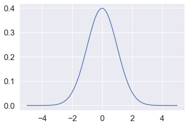

```python
# plot the gaussian pdf
from numpy import arange
from matplotlib import pyplot
from scipy.stats import norm
# define the distribution parameters
sample_space = arange(-5, 5, 0.001)
mean = 0.0
stdev = 1.0
# calculate the pdf
pdf = norm.pdf(sample_space, mean, stdev)
# plot
pyplot.plot(sample_space, pdf)
pyplot.show()
```

## Distribution of SOC

```
 mu = 6.11 and sigma = 5.01
```

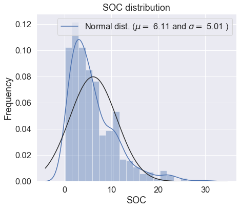

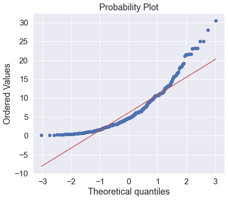

```python
import matplotlib.pyplot as plt
import seaborn as sns
import scipy.stats as st
from scipy.stats import norm

fig = plt.figure(figsize=(7, 6))
sns.distplot(df['SOC'], fit=norm);


# Get the fitted parameters used by the function
(mu, sigma) = norm.fit(df['SOC'])
print( '\n mu = {:.2f} and sigma = {:.2f}\n'.format(mu, sigma))

#Now plot the distribution
plt.legend(['Normal dist. ($\mu=$ {:.2f} and $\sigma=$ {:.2f} )'.format(mu, sigma)],
            loc='best')
plt.ylabel('Frequency')
plt.title('SOC distribution')

#Get also the QQ-plot
fig = plt.figure(figsize=(7, 6))
res =st.probplot(df['SOC'], plot=plt)
plt.show()
```

We can create a nice looking Q-Q plot with "Pingouin". It is an open-source statistical package written in Python 3 and based mostly on Pandas and NumPy.

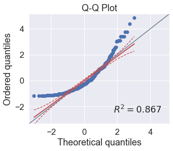

```python
import numpy as np
import pingouin as pg

ax = pg.qqplot(df['SOC'], dist='norm')
```

## Normality Test

"Many of the statistical procedures including correlation, regression, t-tests, and analysis of variance, namely parametric tests, are based on the assumption that the data follows a normal distribution or a Gaussian distribution (after Johann Karl Gauss, 1777–1855); that is, it is assumed that the populations from which the samples are taken are normally distributed. The assumption of normality is especially critical when constructing reference intervals for variables. Normality and other assumptions should be taken seriously, for when these assumptions do not hold, it is impossible to draw accurate and reliable conclusions about reality"

"Visual inspection of the distribution may be used for assessing normality (density plots, histogram), although this approach is usually unreliable and does not guarantee that the distribution is normal. The normality tests are supplementary to the graphical assessment of normality. The main tests for the assessment of normality are Kolmogorov-Smirnov (K-S) test".

Source: Ghasemi A, Zahediasl S. Normality tests for statistical analysis: a guide for non-statisticians. Int J Endocrinol Metab. 2012 Spring;10(2):486-9. doi: 10.5812/ijem.3505. Epub 2012 Apr 20. PMID: 23843808; PMCID: PMC3693611.

In Python, the pingouin.normality() function works with lists, arrays, or pandas DataFrame in wide or long-format.

```python
import numpy as np
import pingouin as pg

print(pg.normality(df['SOC']))
```

```
            W          pval  normal
SOC  0.866947  1.307438e-21   False
```

## Skewness

Two numerical measures of shape - skewness can also be used to test for normality.

"In statistics, skewness is a measure of the asymmetry of the probability distribution of a random variable about its mean. In other words, skewness tells you the amount and direction of skew (departure from horizontal symmetry). The skewness value can be positive or negative, or even undefined. If skewness is 0, the data are perfectly symmetrical, although it is quite unlikely for real-world data. As a general rule of thumb:

[output not shown]

In python, skew() function from scipy.stats can be used to calculate Skewness of a variable

```python
from scipy.stats import skew

skew(df['SOC'])

# so SOC data is highly positively skewed. We also see this in histogram and QQ plots
```

```
1.5317088546155238
```

## Data transformation

In statistical data analysis, transformation is the replacement of one variable by one function of that variable: for example, replacing one variable x by the square root or l the logarithm of x. The transformation is a replacement that changes the shape of a distribution or relationship.

There are many reasons for transformation (source: http://fmwww.bc.edu/repec/bocode/t/transint.html)

```
    1. Reducing skewness or transforming Data for Normality
    2. Equal spreads
    3. Linear relationships
    4. Additive relationships
```

**Transformation Methods** (source:https://www.marsja.se/transform-skewed-data-using-square-root-log-box-cox-methods-in-python/)

As indicated in the introduction, we are going to learn three methods that we can use to transform data deviating from the normal distribution. In this section, you will get a brief overview of these three transformation techniques and when to use them.

**Square Root Transformation**

The square root method is typically used when your data is moderately skewed. Now using the square root (e.g., sqrt(x)) is a transformation that has a moderate effect on distribution shape. It is generally used to reduce right skewed data. Finally, the square root can be applied on zero values and is most commonly used on counted data.

**Power Transformation**

a power transform is a family of functions that are applied to create a monotonic transformation of data using power functions.

**Log Transformation** is a strong transformation that has a major effect on distribution shape. This technique is, as the square root method, oftenly used for reducing right skewness. Worth noting, however, is that it can not be applied to zero or negative values.

The **Box-Cox transformation** is, as you probably understand, also a technique to transform non-normal data into normal shape. This is a procedure to identify a suitable exponent (Lambda = l) to use to transform skewed data.

```
-0.6798075377984538
```

[figure not shown]

```python
import matplotlib.pyplot as plt
import seaborn as sns
import numpy as np
from scipy.stats import skew

df['sqrtSOC'] = np.log(df['SOC']**(0.5))
import matplotlib.pyplot as plt

fig = plt.figure(figsize=(7, 6))
sns.distplot(df['sqrtSOC'], fit=norm)
plt.title('Square Root Transformation')

## Skewness
skew(df['sqrtSOC'])
```

### Logarithm Transformation

Log transformation helps reducing skewness when you have highly skewed data, like SOC data.

```
-0.6798075377984539
```

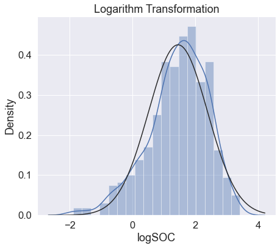

```python
import matplotlib.pyplot as plt
import seaborn as sns
import numpy as np
from scipy.stats import skew

df['logSOC'] = np.log(df['SOC'])

fig = plt.figure(figsize=(7, 6))
sns.distplot(df['logSOC'], fit=norm)
plt.title('Logarithm Transformation')

## Skewness
skew(df['logSOC'])
```

### BoxCox transformation

The boxcox() SciPy function implements the Box-Cox method. It takes an argument, called lambda, that controls the type of transform to perform.

Below are some common values for lambda

If w is our transformed variable and y is our target variable, then

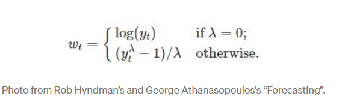

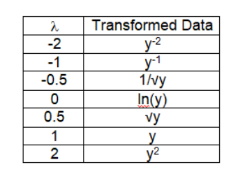

```
-0.6798075377984539
```

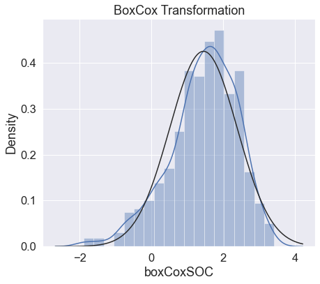

```python
import matplotlib.pyplot as plt
import seaborn as sns
from scipy.stats import boxcox
from scipy.stats import skew

df['boxCoxSOC'] = boxcox(df['SOC'], 0)

fig = plt.figure(figsize=(7, 6))
sns.distplot(df['boxCoxSOC'], fit=norm)
plt.title('BoxCox Transformation')

## Skewness
skew(df['boxCoxSOC'])
```

We can choose the value of lambda that provides the best approximation for the normal distribution of SOC.

Scipy has a boxcox() function that will choose the optimal value of lambda for us.

```python
#perform Box-Cox transformation on original data
from scipy.stats import boxcox
transformed_data, best_lambda = boxcox(df['SOC'])
# display optimal lambda value
print(best_lambda)
```

```
0.25454407284042113
```

The optimal lambda was found to be roughly 0.255, now we will use this values to transform the data

```
-0.02501612633277753
```

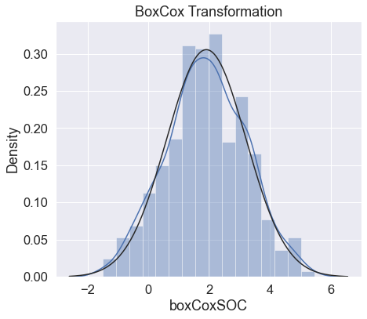

```python
import matplotlib.pyplot as plt
import seaborn as sns
from scipy.stats import boxcox
from scipy.stats import skew

df['boxCoxSOC'] = boxcox(df['SOC'], 0.255)
fig = plt.figure(figsize=(7, 6))
sns.distplot(df['boxCoxSOC'], fit=norm)
plt.title('BoxCox Transformation')

## Skewness
skew(df['boxCoxSOC'])
```

## Back-transformation

Sometimes we need to transformed back the data to original scales

For example, your model might predict that the Box-Cox transformed value, given other features, is 0.255. You need to use this 0.255 and revert it to its original scale (the scale of your target variable).

We will use **scipy.special.inv_boxcox(transformed_vlues, lambda)** to back-tranform to the original scales.

```python
from scipy.stats import boxcox
from scipy.special import inv_boxcox

df['back_boxCoxSOC'] = inv_boxcox(df['boxCoxSOC'], 0.255)
df
```

```
WARNING:itables.downsample:showing 285x20 of 570x20 as nbytes=91200>65536=maxBytes. See https://mwouts.github.io/itables/#downsampling
```

|  | SiteID | long | lat | x | y | FIPS | STATE | COUNTY | SOC | DEM | Slope | MAP | MAT | NDVI | NLCD | NLCD_DES | sqrtSOC | logSOC | boxCoxSOC | back_boxCoxSOC |
| --- | --- | --- | --- | --- | --- | --- | --- | --- | --- | --- | --- | --- | --- | --- | --- | --- | --- | --- | --- | --- |

## Descriptive Statistics

Descriptive statistics are used to describe the basic features of the data in a study. They provide simple summaries about the sample and the measures. Together with simple graphics analysis, they form the basis of virtually every quantitative analysis of data.

**Central Tendency* (source:https://conjointly.com/kb/descriptive-statistics/)

The central tendency of a distribution is an estimate of the “center” of a distribution of values. There are three major types of estimates of central tendency:

```
Mean
Median
Mode
```

The **Mean or average** is probably the most commonly used method of describing central tendency. To compute the mean all you do is add up all the values and divide by the number of values. For example, the mean or average quiz score is determined by summing all the scores and dividing by the number of students taking the exam. For example, consider the test score values:

15, 20, 21, 20, 36, 15, 25, 15

The sum of these 8 values is 167, so the mean is 167/8 = 20.875.

The **Median** is the score found at the exact middle of the set of values. One way to compute the median is to list all scores in numerical order, and then locate the score in the center of the sample. For example, if there are 500 scores in the list, score #250 would be the median. If we order the 8 scores shown above, we would get:

15, 15, 15, 20, 20, 21, 25, 36

There are 8 scores and score #4 and #5 represent the halfway point. Since both of these scores are 20, the median is 20. If the two middle scores had different values, you would have to interpolate to determine the median.

The **Mode** is the most frequently occurring value in the set of scores. To determine the mode, you might again order the scores as shown above, and then count each one. The most frequently occurring value is the mode. In our example, the value 15 occurs three times and is the model. In some distributions there is more than one modal value. For instance, in a bimodal distribution there are two values that occur most frequently.

Notice that for the same set of 8 scores we got three different values (20.875, 20, and 15) for the mean, median and mode respectively. If the distribution is truly normal (i.e., bell-shaped), the mean, median and mode are all equal to each other.

**Dispersion**

Dispersion refers to the spread of the values around the central tendency. There are two common measures of dispersion, the range and the standard deviation. The range is simply the highest value minus the lowest value. In our example distribution, the high value is 36 and the low is 15, so the range is 36 - 15 = 21.

The **Standard Deviation** is a more accurate and detailed estimate of dispersion because an outlier can greatly exaggerate the range (as was true in this example where the single outlier value of 36 stands apart from the rest of the values. The Standard Deviation shows the relation that set of scores has to the mean of the sample.

Again lets take the set of scores:

15, 20, 21, 20, 36, 15, 25, 15

to compute the standard deviation, we first find the distance between each value and the mean. We know from above that the mean is 20.875. So, the differences from the mean are:

15 - 20.875 = -5.875  
20 - 20.875 = -0.875  
21 - 20.875 = +0.125  
20 - 20.875 = -0.875  
36 - 20.875 = 15.125  
15 - 20.875 = -5.875  
25 - 20.875 = +4.125  
15 - 20.875 = -5.875

Notice that values that are below the mean have negative discrepancies and values above it have positive ones. Next, we square each discrepancy:

-5.875 -5.875 = 34.515625  
-0.875 -0.875 = 0.765625  
+0.125 +0.125 = 0.015625  
-0.875 -0.875 = 0.765625  
15.125 15.125 = 228.765625  
-5.875 -5.875 = 34.515625  
+4.125 +4.125 = 17.015625  
-5.875 -5.875 = 34.515625

Now, we take these “squares” and sum them to get the Sum of Squares (SS) value. Here, the sum is 350.875. Next, we divide this sum by the number of scores minus 1. Here, the result is 350.875 / 7 = 50.125. This value is known as the variance. To get the standard deviation, we take the square root of the variance (remember that we squared the deviations earlier). This would be SQRT(50.125) = 7.079901129253.

Although this computation may seem convoluted, it’s actually quite simple. To see this, consider the formula for the standard deviation:

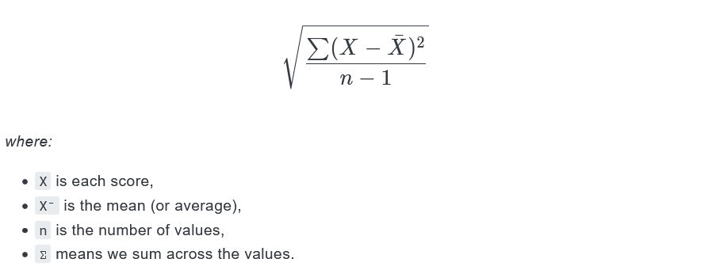

You can use as describe() function to get quantile, median (50% quantile), count, max, mean and min and std of all wuantative values of dataframe.

```python
df[['SOC', 'DEM', 'Slope','MAP', 'MAT','NDVI']].describe()
```

|  | SOC | DEM | Slope | MAP | MAT | NDVI |
| --- | --- | --- | --- | --- | --- | --- |

## Descriptive Statistics by Group

Now we caculate the descriptive statistics by NLCD

```python
# Descriptive statistics
soc_nlcd=df.groupby("NLCD_DES")['SOC'].describe().reset_index()
soc_nlcd
```

| NLCD_DES | count | mean | std | min | 25% | 50% | 75% | max |
| --- | --- | --- | --- | --- | --- | --- | --- | --- |

We also calculate the stanadrard error of mean using following formula:

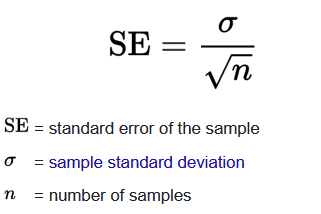

```python
# Standard error
soc_nlcd['count_squareroot']=soc_nlcd['count']**(1/2)
soc_nlcd['sem']= soc_nlcd['std']/soc_nlcd['count_squareroot']
# acending data
mf_soc_nlcd=soc_nlcd.sort_values("mean",ascending=False)
mf_soc_nlcd
```

|  | NLCD_DES | count | mean | std | min | 25% | 50% | 75% | max | count_squareroot | sem |
| --- | --- | --- | --- | --- | --- | --- | --- | --- | --- | --- | --- |

## Bar Plot

```python
import numpy as np

# Create lists for the plot
NLCD = mf_soc_nlcd['NLCD_DES']
x_pos = np.arange(len(NLCD))
SOC = mf_soc_nlcd['mean']
error =mf_soc_nlcd ['sem']
```

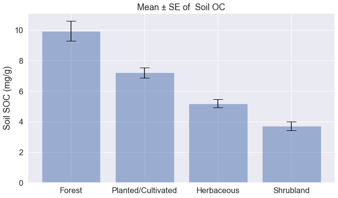

```python
import matplotlib.pyplot as plt

fig, ax = plt.subplots(figsize=(10, 6))
ax.bar(NLCD, SOC, yerr=error, align='center', alpha=0.5, ecolor='black', capsize=10)
ax.set_ylabel('Soil SOC (mg/g)')
ax.set_xticks(x_pos)
ax.set_xticklabels(NLCD)
ax.set_title('Mean ± SE of  Soil OC')
ax.yaxis.grid(True)

# Save the figure and show
plt.tight_layout()
# plt.savefig('bar_plot_with_error_bars.png')
plt.show()
```

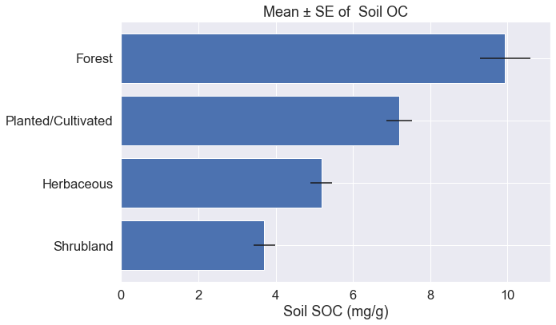

```python
### Horizontal Barplot
y_pos = np.arange(len(NLCD))
SOC = mf_soc_nlcd['mean']
error =mf_soc_nlcd ['sem']

import matplotlib.pyplot as plt

fig, ax = plt.subplots(figsize=(10, 6))

ax.barh(NLCD, SOC, xerr=error, align='center')
ax.set_yticks(NLCD)
ax.set_yticklabels(NLCD)
ax.invert_yaxis()  # labels read top-to-bottom
ax.set_xlabel('Soil SOC (mg/g)')
ax.set_title('Mean ± SE of  Soil OC')
ax.yaxis.grid(True)

# Save the figure and show
plt.tight_layout()
# plt.savefig('bar_plot_with_error_bars.png')
plt.show()
```

## Boxplot

In descriptive statistics, a box plot or boxplot is a method for graphically depicting groups of numerical data through their quartiles. Box plots may also have lines extending from the boxes indicating variability outside the upper and lower quartiles, hence the terms box-and-whisker plot and box-and-whisker diagram (Wikepedia)

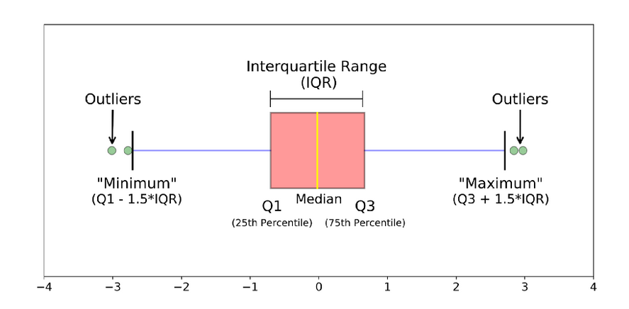

"The image above is a boxplot. A boxplot is a standardized way of displaying the distribution of data based on a five number summary (“minimum”, first quartile (Q1), median, third quartile (Q3), and “maximum”). It can tell you about your outliers and what their values are. It can also tell you if your data is symmetrical, how tightly your data is grouped, and if and how your data is skewed".

- median (Q2/50th Percentile): the middle value of the dataset.
- first quartile (Q1/25th Percentile): the middle number between the smallest number (not the “minimum”) and the median of the dataset.
- third quartile (Q3/75th Percentile): the middle value between the median and the highest value (not the “maximum”) of the dataset.
- interquartile range (IQR): 25th to the 75th percentile.
- whiskers (shown in blue)

outliers (shown as green circles)

- “maximum”: Q3 + 1.5*IQR
- “minimum”: Q1 -1.5*IQR

source: https://towardsdatascience.com/understanding-boxplots-5e2df7bcbd51

### Boxplot with Seaborn and Matplotlib

We will create a boxplot of soil organic carbon (SOC) in realtion to landuse and landover (NLCD_DES)

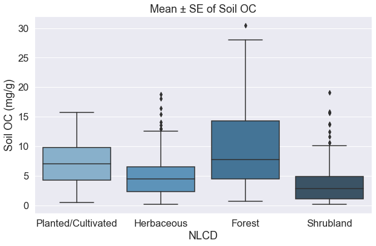

```python
import seaborn as sns
import matplotlib.pyplot as plt

p, ax = plt.subplots(figsize=(10, 6))
ax=sns.boxplot(y="SOC",
            x="NLCD_DES",
            data=df,
            palette="Blues_d")

ax.axes.xaxis.label.set_text("NLCD")
ax.axes.yaxis.label.set_text("Soil OC (mg/g)")
plt.title('Mean ± SE of Soil OC')
```

### Interactive Boxplot with Plotly

We can create a intercative boxplots in Python using Plotly package, that are grouped, colored, and display the underlying data distribution.

```python
import plotly.express as px

fig = px.box(df,
             x="NLCD_DES",
             y="SOC",
             width=800,
             height=500
             )
fig.update_layout(
    title={
        'text': "Sourface Soil Organic (mg/g)",
        'y':0.95,
        'x':0.5,
        'xanchor': 'center',
        'yanchor': 'top'},
     xaxis_title="NLCD",
     yaxis_title="Soil OC",
     font=dict(
        family="sans-serif, monospace",
        size=18,
        color="#7f7f7f"))

fig.show()
```

[interactive chart not shown]

### Boxplot SOC for 4 States

```python
import plotly.express as px

fig = px.box(df,
             x="STATE",
             y="SOC",
             width=800,
             height=500,
             color="NLCD_DES")
fig.update_layout(
    title={
        'text': "Sourface Soil Organic (mg/g)",
        'y':0.95,
        'x':0.5,
        'xanchor': 'center',
        'yanchor': 'top'},
     xaxis_title="NLCD",
     yaxis_title="Soil OC",
     font=dict(
        family="sans-serif, monospace",
        size=18,
        color="#7f7f7f"))

fig.show()
```

[interactive chart not shown]

# Basic Statistical Analysis

## One-way Analysis of Variance (ANOVA)

- The one-way analysis of variance (ANOVA) is used to determine whether there are any statistically significant differences between the means of three or more independent (unrelated) groups.
- Groups mean differences inferred by analyzing variances
- ANOVA uses variance-based F test to check the group mean equality. Sometimes, ANOVA F test is also called omnibus test as it tests non-specific null hypothesis i.e. all group means are equal
- Main types: One-way (one factor) and two-way (two factors) ANOVA (factor is an independent variable)
- If you have repeated measurements for treatments or time on same subjects, you should use Repeated Measure ANOVA

**ANOVA Hypotheses**

Null hypothesis: Groups means are equal (no variation in means of groups) H0: μ1=μ2=…=μp

**Alternative hypothesis**: At least, one group mean is different from other groups H1: All μ are not equal Learn more about hypothesis testing and interpretation

**ANOVA Assumptions**

- Residuals (experimental error) are normally distributed (Shapiro-Wilks Test)
- Homogeneity of variances (variances are equal between treatment groups) (Levene’s or Bartlett’s Test)
- Observations are sampled independently from each other

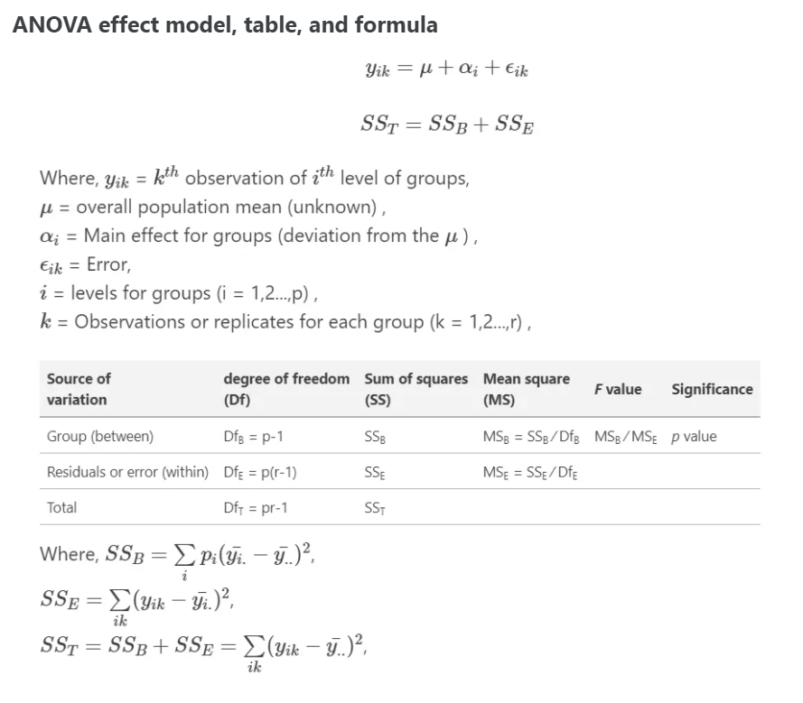

Source: https://www.reneshbedre.com/blog/anova.html

We use anova() fuction of pingouin package to see statistical differences of mean SOC among the NLCD classes.

```python
import numpy as np
import pingouin as pg

aov = pg.anova(data=df, dv='SOC', between='NLCD_DES', detailed=True)
aov
```

| Source | SS | DF | MS | F | p-unc | np2 |
| --- | --- | --- | --- | --- | --- | --- |

Get ANOVA table as R like output using statsmodels packages

```python
import statsmodels.api as sm
from statsmodels.formula.api import ols

# Ordinary Least Squares (OLS) model
model = ols('SOC ~ C(NLCD_DES)', data=df).fit()
anova_table = sm.stats.anova_lm(model, typ=2)
anova_table
```

|  | sum_sq | df | F | PR(>F) |
| --- | --- | --- | --- | --- |

#### Interpretation

The p value obtained from ANOVA analysis is significant (p < 0.05), and therefore, we conclude that there are significant differences in SOC content among the NLCD

### Tukey’s HSD test

From ANOVA analysis, we know that treatment differences are statistically significant, but ANOVA does not tell which treatments are significantly different from each other. To know the pairs of significant different treatments, we will perform multiple pairwise comparison (post hoc comparison) analysis for all unplanned comparison using Tukey’s honestly significantly differenced (HSD) test. (Source:https://www.reneshbedre.com/blog/anova.html)

Tukey’s HSD test accounts for multiple comparisons and corrects for family-wise error rate (FWER) (inflated type I error)

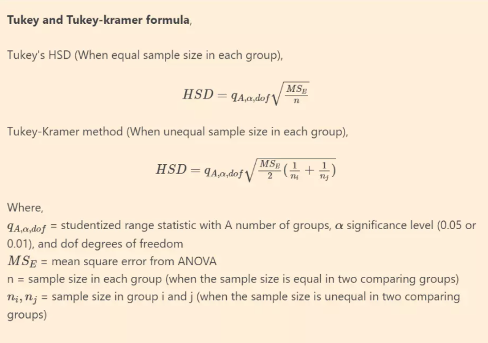

To perform Tukey’s test in Python, we can use the pairwise_tukeyhsd() function from the statsmodels library

```python
from statsmodels.stats.multicomp import pairwise_tukeyhsd

tukey = pairwise_tukeyhsd(endog=df['SOC'],
                          groups=df['NLCD_DES'],
                          alpha=0.05)

print(tukey)
```

```
            Multiple Comparison of Means - Tukey HSD, FWER=0.05
============================================================================
      group1             group2       meandiff p-adj   lower   upper  reject
----------------------------------------------------------------------------
            Forest         Herbaceous  -4.7472  0.001 -6.1242 -3.3703   True
            Forest Planted/Cultivated  -2.7317  0.001 -4.2738 -1.1897   True
            Forest          Shrubland  -6.2282  0.001 -7.6455 -4.8108   True
        Herbaceous Planted/Cultivated   2.0155 0.0012  0.6271  3.4039   True
        Herbaceous          Shrubland   -1.481 0.0125 -2.7294 -0.2325   True
Planted/Cultivated          Shrubland  -3.4964  0.001 -4.9249 -2.0679   True
----------------------------------------------------------------------------
```

## Two-way ANOVA

A two-way ANOVA is used to estimate how the mean of a quantitative variable changes according to the levels of two categorical variables. Use a two-way ANOVA when you want to know how two independent variables, in combination, affect a dependent variable. (source: https://www.scribbr.com/statistics/two-way-anova/)

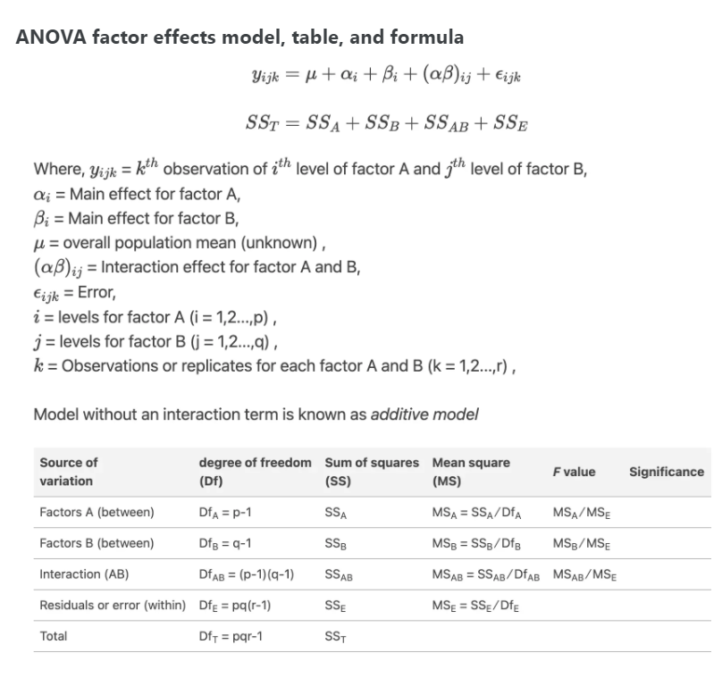

We will rice grain arsenic (As) data in 6 genotypes grown in tow types of soil: High soil As and Low soil As

```python
import pandas as pd

mf_id = 'Grain_arsenic_data.csv'
mf = pd.read_csv(mf_id)
mf.columns
```

```
Index(['ID', 'Soil_As', 'Genotype', 'Replication', 'Grain_As'], dtype='object')
```

```python
# Box Plot: differences between different groups

import plotly.express as px

fig = px.box(mf,
             x="Genotype",
             y="Grain_As",
             width=800,
             height=500,
             color="Soil_As")
fig.update_layout(
    title={
        'text': "Rice Grain As content (mg/Kg)",
        'y':0.95,
        'x':0.5,
        'xanchor': 'center',
        'yanchor': 'top'},
     xaxis_title="Genotypes",
     yaxis_title="Grain As",
     font=dict(
        family="sans-serif, monospace",
        size=18,
        color="#7f7f7f"))

fig.show()
```

[interactive chart not shown]

```python
import statsmodels.api as sm
from statsmodels.formula.api import ols

#perform two-way ANOVA
model_2 = ols('Grain_As ~ C(Soil_As) + C(Genotype) + C(Soil_As):C(Genotype)', data=mf).fit()
sm.stats.anova_lm(model_2, typ=2)
```

|  | sum_sq | df | F | PR(>F) |
| --- | --- | --- | --- | --- |

## Correlation Analysis

**What is correlation?**

Correlation is a statistical measure that expresses the extent to which two variables are linearly related (meaning they change together at a constant rate). It’s a common tool for describing simple relationships without making a statement about cause and effect.

**How is correlation measured?**

The sample correlation coefficient, **r**, quantifies the strength of the relationship. Correlations are also tested for statistical significance.

**What are some limitations of correlation analysis?**

Correlation can’t look at the presence or effect of other variables outside of the two being explored. Importantly, correlation doesn’t tell us about cause and effect. Correlation also cannot accurately describe curvilinear relationships.

**What do correlation numbers mean?**

We describe correlations with a unit-free measure called the correlation coefficient which ranges from -1 to +1 and is denoted by r. Statistical significance is indicated with a p-value. Therefore, correlations are typically written with two key numbers: r = and p = .

- The closer r is to zero, the weaker the linear relationship.
- Positive r values indicate a positive correlation, where the values of both variables tend to increase together.
- Negative r values indicate a negative correlation, where the values of one variable tend to increase when the values of the other variable decrease.
- The p-value gives us evidence that we can meaningfully conclude that the population correlation coefficient is likely different from zero, based on what we observe from the sample.
- "Unit-free measure" means that correlations exist on their own scale: in our example, the number given for r is not on the same scale as either elevation or temperature. This is different from other summary statistics. For instance, the mean of the elevation measurements is on the same scale as its variable.

**What is a p-value?**

- A p-value is a measure of probability used for hypothesis testing.
- It indicates the likelihood of obtaining the data that we are seeing if there is no effect present — in other words, in the case of the null hypothesis. For our campsite data, this would be the hypothesis that there is no linear relationship between elevation and temperature. When a p-value is used to describe a result as statistically significant, this means that it falls below a pre-defined cutoff (e.g., p <.05 or p <.01) at which point we reject the null hypothesis in favor of an alternative hypothesis (for our campsite data, that there is a relationship between elevation and temperature).

**Pearson’s Correlation**

- The Pearson correlation coefficient (named for Karl Pearson) can be used to summarize the strength of the linear relationship between two data samples.
- The Pearson’s correlation coefficient is calculated as the covariance of the two variables divided by the product of the standard deviation of each data sample. It is the normalization of the covariance between the two variables to give an interpretable score.

(source: https://www.jmp.com/en_us/statistics-knowledge-portal/what-is-correlation.html)

**Spearman’s Correlation**

Two variables may be related by a nonlinear relationship, such that the relationship is stronger or weaker across the distribution of the variables.

Further, the two variables being considered may have a non-Gaussian distribution.

In this case, the Spearman’s correlation coefficient (named for Charles Spearman) can be used to summarize the strength between the two data samples. This test of relationship can also be used if there is a linear relationship between the variables, but will have slightly less power (e.g. may result in lower coefficient scores).

As with the Pearson correlation coefficient, the scores are between -1 and 1 for perfectly negatively correlated variables and perfectly positively correlated respectively.

(Source: https://machinelearningmastery.com/how-to-use-correlation-to-understand-the-relationship-between-variables/)

### Pearson Correlation of two variables: Soil Organic Crabon and NDVI (Normalize Vegetation Index Diffrence)

```python
from scipy.stats import pearsonr

(r, p) = pearsonr(df['SOC'], df['NDVI'])
print( '\n r = {:.3f} and p-value = {:.3f}\n'.format(r, p))
```

```
 r = 0.598 and p-value = 0.000
```

We can see that the two variables are positively correlated and that the correlation is 0.6. This suggests that soil organic carbon is moderetly related to the NDVI.

### Spearman’s Correlation of two variables: SOC and NDVI

```python
from scipy.stats import spearmanr

(r,p) = spearmanr(df['SOC'], df['NDVI'])
print( '\n r = {:.3f} and p-value = {:.3f}\n'.format(r, p))
```

```
 r = 0.657 and p-value = 0.000
```

Spearman correltion coefficient value is little higher than Pearson correlation coefficent.

### Visualizing correlations with scatterplots

```
 r = 0.598 and p-value = 0.000
```

```
<module 'matplotlib.pyplot' from 'E:\\DSM\\lib\\site-packages\\matplotlib\\pyplot.py'>
```

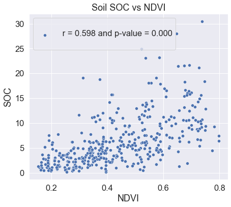

```python
import seaborn as sns
import matplotlib.pyplot as plt

# Scatter plots
fig = plt.figure(figsize=(7, 6))
sns.scatterplot(y="SOC",
            x="NDVI",
            data=df)

# Get Pearson r and p-values
(r, p) = pearsonr(df['SOC'], df['NDVI'])
print( '\n r = {:.3f} and p-value = {:.3f}\n'.format(r, p))
# Add r nad p-values on the plot
plt.legend(['\n r = {:.3f} and p-value = {:.3f}\n'.format(r, p)],
            loc='best')
plt.title('Soil SOC vs NDVI')
plt
```

### Interactive 3D scater plot with Plotly

```python
import plotly.graph_objects as go
import plotly.express as px

px.scatter_3d(df, x='NDVI', y='MAT', z='SOC',
                    color='SOC',
                    size='SOC', size_max=18,
                    opacity=0.7)
```

[interactive chart not shown]

### Mariginal plot with Seaborn

A marginal plot allows to study the relationship between 2 numeric variables. The central chart display their correlation. It is usually a scatterplot, a hexbin plot, a 2D histogram or a 2D density plot. The marginal charts, usually at the top and at the right, show the distribution of the 2 variables using histogram or density plot.

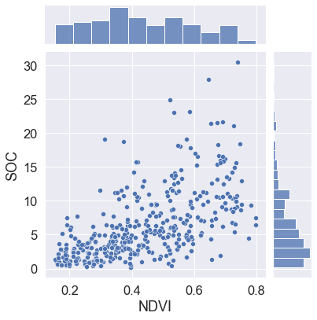

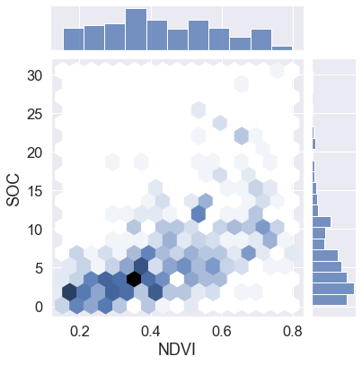

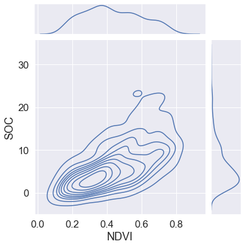

```python
import seaborn as sns

sns.jointplot(x=df["NDVI"], y=df["SOC"], kind='scatter')
sns.jointplot(x=df["NDVI"], y=df["SOC"], kind='hex')
sns.jointplot(x=df["NDVI"], y=df["SOC"], kind='kde')
```

### Correlation Matrix

A correlation matrix is a table or plots showing correlation coefficients between sets of variables. correlation matrix is used to summarize data, as an input into a more advanced analysis, and as a diagnostic for advanced analyses.

We will create data-frame with all continous varibles to get corrlation among them.

```python
mf=df[['SOC', 'DEM', 'Slope','MAP', 'MAT','NDVI']]
```

```python
mf.corr()
```

|  | SOC | DEM | Slope | MAP | MAT | NDVI |
| --- | --- | --- | --- | --- | --- | --- |

You can use pg.pairwise_corr() function from Pingouin pakage to get more detail statistics of pair-wise correlation analysis

```python
import numpy as np
import pingouin as pg

pg.pairwise_corr(mf, columns=['SOC', 'DEM', 'Slope','MAP', 'MAT','NDVI'], method='pearson')
```

| X | Y | method | tail | n | r | CI95% | r2 | adj_r2 | z | p-unc | BF10 | power |
| --- | --- | --- | --- | --- | --- | --- | --- | --- | --- | --- | --- | --- |

### Heatmap

You can use sns.heatmap() function seaborn package to create nice looking heat-map to visualize correlation among a set of variables

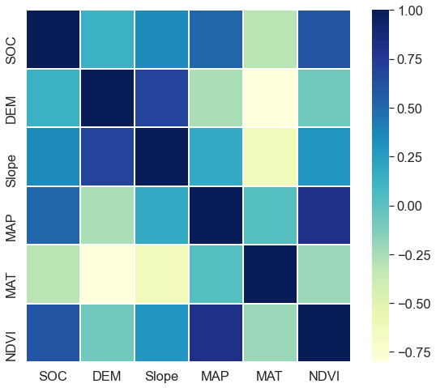

```python
import matplotlib.pyplot as plt
import seaborn as sns

corrmat = mf.corr()
f, ax = plt.subplots(figsize =(9, 8))
sns.heatmap(corrmat, ax = ax, cmap ="YlGnBu", linewidths = 0.1)
```

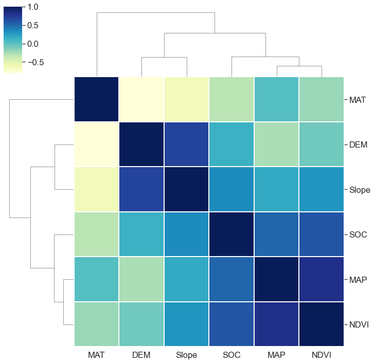

```python
# Cluster grid maps

import matplotlib.pyplot as plt
import seaborn as sns

cg = sns.clustermap(corrmat, cmap ="YlGnBu", linewidths = 0.1);
plt.setp(cg.ax_heatmap.yaxis.get_majorticklabels(), rotation = 0)

cg
```

### Correlation Matrix Scatter Plot With Pandas

Several python packages allows to make a correlogram or correlation matrix really easily. Correlogram are awesome for exploratory analysis: it allows to quickly observe the relationship between every variable of your matrix.

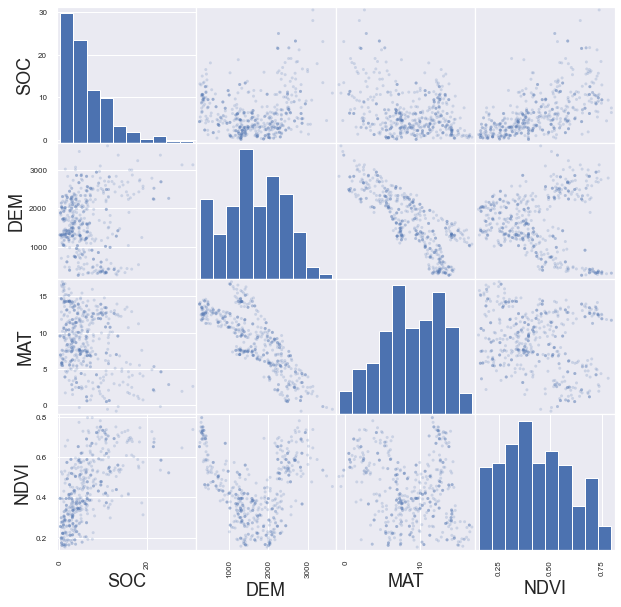

```python
import pandas as pd
import matplotlib.pyplot as plt

pd.plotting.scatter_matrix(mf[['SOC', 'DEM', 'MAT','NDVI']], alpha=0.2, figsize=(10, 10))
plt.show()
```

### Correlation Matrix Plot With Seaborn

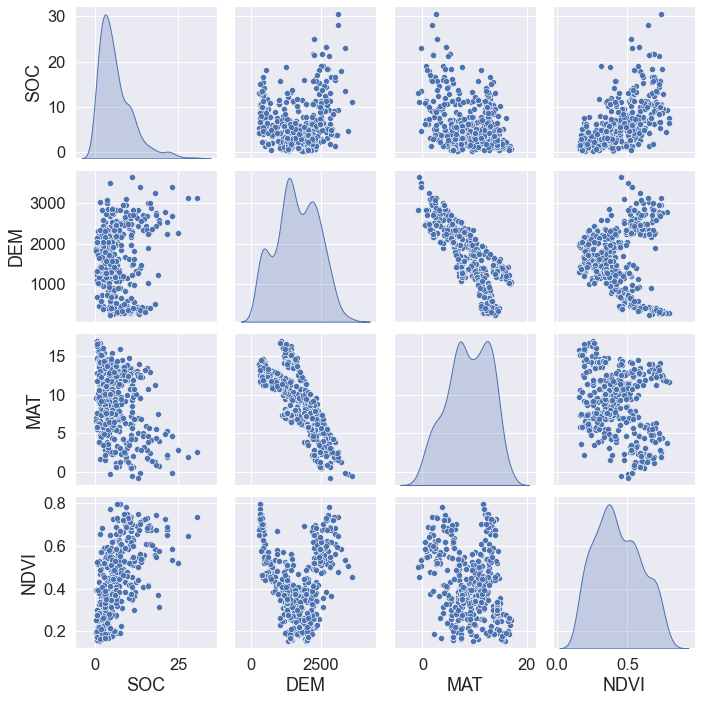

```python
import seaborn as sns

sns.pairplot(mf[['SOC', 'DEM', 'MAT','NDVI']], diag_kind="kde")
```

## **Regression Analysis**

"Regression analysis is a way of mathematically sorting out which of those variables does indeed have an impact. It answers the questions: Which factors matter most? Which can we ignore? How do those factors interact with each other? And, perhaps most importantly, how certain are we about all of these factors?" (source: https://hbr.org/2015/11/a-refresher-on-regression-analysis)

"Regression analysis is a way to find trends in data. For example, you might guess that there’s a connection between how much you eat and how much you weigh; regression analysis can help you quantify that". (source: https://www.statisticshowto.com/probability-and-statistics/regression-analysis/).

In statistics "Regression analysis is a set of statistical methods used for the estimation of relationships between a dependent variable and one or more independent variables. It can be utilized to assess the strength of the relationship between variables and for modeling the future relationship between them". (source:https://corporatefinanceinstitute.com/resources/knowledge/finance/regression-analysis/)

Regression analysis includes several variations, such as linear, multiple linear, and nonlinear. The most common models are simple linear and multiple linear. Nonlinear regression analysis is commonly used for more complicated data sets in which the dependent and independent variables show a nonlinear relationship. (source:https://corporatefinanceinstitute.com/resources/knowledge/finance/regression-analysis/)

**Regression Analysis – Linear model assumptions**

Linear regression analysis is based on six fundamental assumptions:

- The dependent and independent variables show a linear relationship between the slope and the intercept.
- The independent variable is not random.
- The value of the residual (error) is zero.
- The value of the residual (error) is constant across all observations.
- The value of the residual (error) is not correlated across all observations.
- The residual (error) values follow the normal distribution

  (source:https://corporatefinanceinstitute.com/resources/knowledge/finance/regression-analysis/)

### **Regression Analysis – Simple linear regression**

Simple linear regression is a model that assesses the relationship between a dependent variable and an independent variable. The simple linear model is expressed using the following equation:

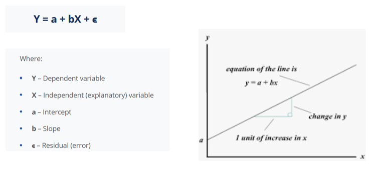

We will use "scikit-learn", a machine learning library for the Python programming language.It features various classification, regression and clustering algorithms including support vector machines, random forests, gradient boosting, k-means and DBSCAN, and is designed to interoperate with the Python numerical and scientific libraries NumPy and SciPy (Wikipedia).

### Define X (predictors) and y (response) variables

```python
x = mf['NDVI'].values.reshape(-1,1)
y = mf['SOC'].values.reshape(-1,1)
```

### Split data training data (75%) and test data (a hold-out data set to evaluate the performane of the regression model) (25%)

```python
from sklearn.model_selection import train_test_split

x_train, x_test, y_train, y_test = train_test_split(
    x, y, test_size=0.25, random_state=42)
```

```python
print(x_train.shape)
print(y_test.shape)
print(y_train.shape)
print(y_test.shape)
```

```
(427, 1)
(143, 1)
(427, 1)
(143, 1)
```

### Standardize features or predictors (x)

It is good practice to normalize or standardize features that use different scales and ranges. Although the model might converge without feature normalization, it makes training more difficult, and it makes the resulting model dependent on the choice of units used in the input.

```python
from sklearn import preprocessing

x_train = preprocessing.scale(x_train)
x_test = preprocessing.scale(x_test)
```

### Training a SLR model

```python
from sklearn.linear_model import LinearRegression

slr = LinearRegression()
slr=slr.fit(x_train, y_train) #training the algorithm
```

```python
# Intercept (a)
print('Intercept:', slr.intercept_)
# Slope (b)
print('Slope:', slr.coef_)
```

```
Intercept: [6.16803279]
Slope: [[3.0336134]]
```

### Regression Residuals

"When you perform simple linear regression (or any other type of regression analysis), you get a line of best fit. The data points usually don’t fall exactly on this regression equation line; they are scattered around. A residual is the vertical distance between a data point and the regression line. Each data point has one residual. They are positive if they are above the regression line and negative if they are below the regression line. If the regression line actually passes through the point, the residual at that point is zero". (source: https://www.statisticshowto.com/residual/)

The residual(e) can also be expressed with an equation. The e is the difference between the predicted value (ŷ) and the observed value. The scatter plot is a set of data points that are observed, while the regression line is the prediction.

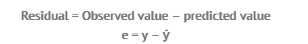

```python
# Prediction at training data
y_train_pred=slr.predict(x_train)

# Create PD data-frame
train_pred= pd.DataFrame({'Actual': y_train.flatten(), 'Predicted': y_train_pred.flatten()})

# calculate the resuduals
train_pred['residuals']=train_pred['Actual'] - train_pred['Predicted']
train_pred
```

| Actual | Predicted | residuals |
| --- | --- | --- |

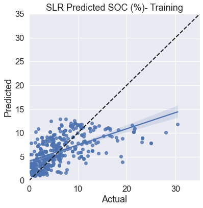

```python
import matplotlib.pyplot as plt
import seaborn as sns

plt.figure(figsize=(6, 6))
ax = sns.regplot(x="Actual", y="Predicted", data=train_pred)
ax.set_ylim(0,35)
ax.set_xlim(0,35)
ax.plot([0, 35], [0, 35], 'k--', lw=2)
plt.title('SLR Predicted SOC (%)- Training',fontsize=18)
```

Now we evaluate the performance of the algorithm. or regression algorithms, three evaluation metrics are commonly used:

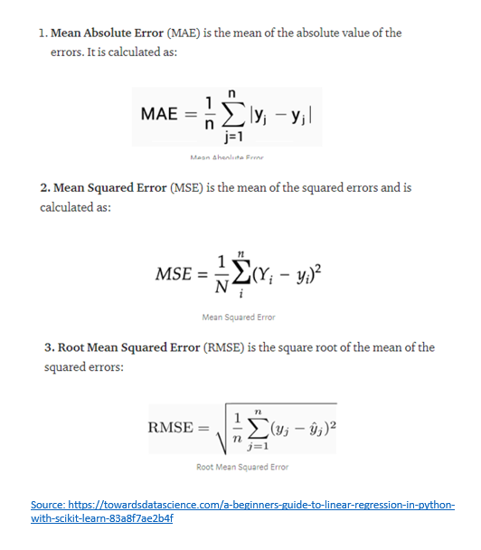

```python
from sklearn import metrics

print('Mean Absolute Error:', metrics.mean_absolute_error(y_train, y_train_pred))
print('Mean Squared Error:', metrics.mean_squared_error(y_train, y_train_pred))
print('Root Mean Squared Error:', np.sqrt(metrics.mean_squared_error(y_train, y_train_pred)))
print('R2:', metrics.r2_score(y_train, y_train_pred))
```

```
Mean Absolute Error: 3.0019433509091815
Mean Squared Error: 17.876310139557376
Root Mean Squared Error: 4.228038568835125
R2: 0.3398489355302675
```

### Prediction at test locations to evaluate the SLR model

Now that we have trained our algorithm, it’s time to make some predictions. To do so, we will use our test data and see how accurately SRL predicts the SOC.

```python
y_slr_pred = slr.predict(x_test)
slr_pred = pd.DataFrame({'Observed': y_test.flatten(), 'Predicted': y_slr_pred.flatten()})
slr_pred
```

| Observed | Predicted |
| --- | --- |

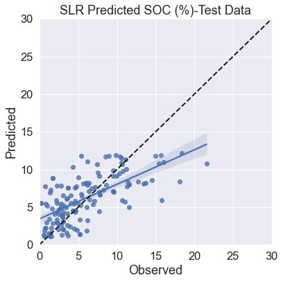

```python
import matplotlib.pyplot as plt
import seaborn as sns

plt.figure(figsize=(6, 6))
ax = sns.regplot(x="Observed", y="Predicted", data=slr_pred)
ax.set_ylim(0,30)
ax.set_xlim(0,30)
ax.plot([0, 30], [0, 30], 'k--', lw=2)
plt.title('SLR Predicted SOC (%)-Test Data',fontsize=18)
```

```python
from sklearn import metrics

print('Mean Absolute Error:', metrics.mean_absolute_error(y_test, y_slr_pred))
print('Mean Squared Error:', metrics.mean_squared_error(y_test, y_slr_pred))
print('Root Mean Squared Error:', np.sqrt(metrics.mean_squared_error(y_test, y_slr_pred)))
print('R2:', metrics.r2_score(y_test, y_slr_pred))
```

```
Mean Absolute Error: 2.4996874518375476
Mean Squared Error: 10.84259895587877
Root Mean Squared Error: 3.292810191292351
R2: 0.42862832607715173
```